# Bayesian Network

Haipeng Yu https://haipengu.github.io/ Gota Morota http://morotalab.org/

2019/11/25

## Introduction

A Bayesian network (BN) describes the joint probability distribution of random variables through their conditional dependencies/independencies and represents as a graphical model (directed acyclic graph)(Scutari and Denis 2014). Thus, a BN provides an approach to decipher the probabilistic dependencies among variables of interest and has been applied in plant and animal genetics (G. Morota et al. 2012; Yu et al. 2019).

In the following examples, we use the `bnlearn` package (Scutari 2010) to infer the BN of seven rice phenotypes including Na+, K+, and Na+: K+ content in roots and shoots (Yu et al. 2019). The rice genotypes are from the Rice Diversity Panel 1 (Zhao et al. 2011). We will use two different approaches to infer BN: 1) data-driven approach and 2) the combination of the data-driven approach and prior knowledge. You can download the rice dataset [here](https://github.com/HaipengU/Data_file).

## Load R packages

```r
# install.packages("bnlearn")
library(bnlearn)
# install.packages("cowplot")
library(cowplot)
# install.packages("ggplot2")
library(ggplot2)
# install.packages("gaston")
library(gaston)
# install.packages("BiocManager")
# BiocManager::install("Rgraphviz")
library(Rgraphviz)
# install.packages("devtools")
library(devtools)
# install_github("QuantGen/MTM")
library(MTM)
```

## Data import

```r
rm(list = ls())

# Import phenotypes
pheno <- read.csv("salt_phenotypes.csv", row.names = 1)
dim(pheno) # 385   7
```

```
## [1] 385   7
```

```r
pheno <- na.omit(pheno) # remove NAs
dim(pheno) # 366   7
```

```
## [1] 366   7
```

```r
head(pheno)
```

```
##           Na.K.Shoot  Na.Shoot K.Shoot.Salt K.Shoot.Control Na.K.Root
## NSFTV_1     217.9371 0.1949661    0.8960666       0.9117648  500.9474
## NSFTV_10    137.4868 0.1250447    0.9109011       0.9235181  427.0097
## NSFTV_100   165.0296 0.1667733    1.0206480       1.0795380  454.0931
## NSFTV_101   146.2632 0.1574553    1.1010989       1.0868638  466.6072
## NSFTV_102   187.6632 0.1537053    0.8338489       0.9042839  522.5943
## NSFTV_103   119.3382 0.1102053    0.9420989       1.0959358  383.7196
##             Na.Root K.Root.Salt
## NSFTV_1   0.2933769   0.6045812
## NSFTV_10  0.2970459   0.7066461
## NSFTV_100 0.3127060   0.6728234
## NSFTV_101 0.3068186   0.6662068
## NSFTV_102 0.4205350   0.8076836
## NSFTV_103 0.2723217   0.7132342
```

```r
# Import genotype
geno <- read.bed.matrix("sativas413")
```

```
## Reading sativas413.fam
## Reading sativas413.bim
## Reading sativas413.bed
## ped stats and snps stats have been set.
## 'p' has been set.
## 'mu' and 'sigma' have been set.
```

```r
dim(geno) # 413 36901
```

```
## [1]   413 36901
```

```r
## Subset accesions with both genotype and phenotype records
geno@ped$id <- paste0("NSFTV_", geno@ped$id)
geno <- geno[geno@ped$id %in% row.names(pheno), ]
dim(geno) # 363 36901
```

```
## [1]   363 36901
```

```r
pheno <- pheno[match(geno@ped$id, row.names(pheno)), ]
dim(pheno) # 363   7
```

```
## [1] 363   7
```

```r
## Check if the ids of genotypes and phenotypes are identical
table(geno@ped$id == rownames(pheno))
```

```
##
## TRUE
##  363
```

## Construct a genomic relationship matrix

```r
# Quality control of genotypes
geno <- select.snps(geno, c(maf > 0.05 & callrate > 0.9))
dim(geno) # 363 29499
```

```
## [1]   363 29499
```

```r
# Construct a genomic relationship matrix
grm <- GRM(geno)
dim(grm) # 363 363
```

```
## [1] 363 363
```

## Fit a multivariate mixed model to obtain estimated breeding values (EBV)

```r
# Define the MTM_func using the MTM Package
MTM_func <- function(Y, G, nTrait, nIter, burnIn, thin, prefix) {
  library(MTM)
  set.seed(007) # reproducible results
  MTM ( Y = Y, K = list ( list ( K = G, COV = list ( type = 'UN', df0 = nTrait,
        S0 = diag (nTrait) ) ) ), resCov = list ( type = 'UN', S0 = diag (nTrait),
        df0 = nTrait), nIter = nIter, burnIn = burnIn, thin = thin, saveAt = prefix)
}

Y <- scale(pheno, center = TRUE, scale = TRUE)
G <- grm
nTrait <- ncol(Y)
MTM_fit <- MTM_func(Y = Y, G = G, nTrait = nTrait, nIter = 1200, burnIn = 200, thin = 5, prefix  = 'MTM_fit')

## Check Gibbs samples
list.files(pattern = 'MTM_fit')
## Retrieve estimates
str(MTM_fit)
BV <- MTM_fit$K[[1]]$U # estimated breeding values
dim(BV) # 363   7
head(BV)
colnames(BV) <- colnames(pheno)
BV <- as.data.frame(BV)
head(BV)
```

## Structure learning using EBV

```r
## Check strength and direction in BN
check_boot <- function(boot, Strength_Thres, Direction_Thres) {
  boot[(boot$strength >= Strength_Thres) & (boot$direction > Direction_Thres),]
}
```

### Structure learning: data-driven approach

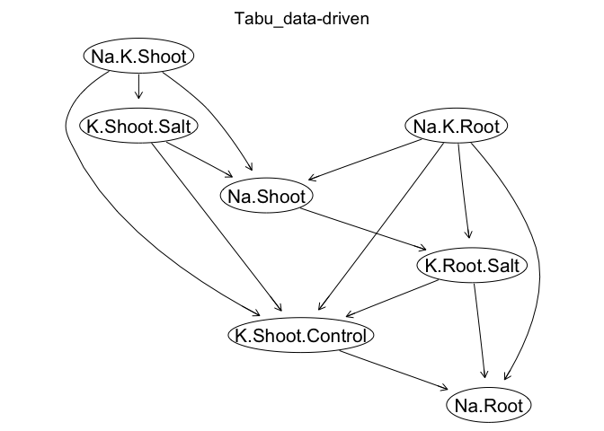

```r
# Score-based algorithm: Tabu Search
tabu_simple <- tabu(BV)
graphviz.plot(tabu_simple, main = "Tabu_data-driven", shape = "ellipse",
              layout = "dot")
```

```r
# Model Averaging with 500 bootstrap samples to account for uncertainty
set.seed(007)
boot_tabu <- boot.strength (BV, algorithm = "tabu", R = 500)
# Check strength (>= 0.8) and direction (> 0.5)
check_boot(boot_tabu, 0.8, 0.5)
```

```
##            from              to strength direction
## 1    Na.K.Shoot        Na.Shoot    1.000 0.9470000
## 2    Na.K.Shoot    K.Shoot.Salt    1.000 0.5360000
## 12     Na.Shoot     K.Root.Salt    0.896 0.8649554
## 14 K.Shoot.Salt        Na.Shoot    0.976 0.9303279
## 15 K.Shoot.Salt K.Shoot.Control    1.000 0.9420000
## 28    Na.K.Root K.Shoot.Control    0.946 0.9704017
## 29    Na.K.Root         Na.Root    1.000 0.9960000
## 30    Na.K.Root     K.Root.Salt    1.000 0.9960000
## 40  K.Root.Salt K.Shoot.Control    0.988 0.7419028
## 42  K.Root.Salt         Na.Root    1.000 0.7510000
```

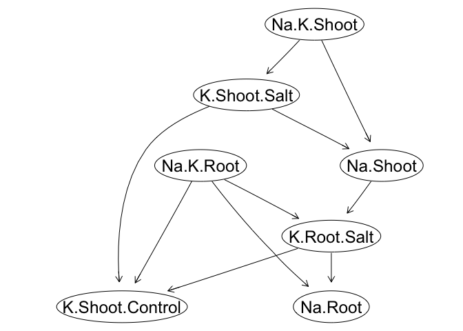

```r
# Average bootstrap samples using threshold = 0.8
ave_model_tabu <- averaged.network(boot_tabu, threshold = 0.8)
graphviz.plot(ave_model_tabu, shape = 'ellipse')
```

### Structure learning: data + prior knowledge

If prior knowledge regarding the network structure is available, it is possible to incorporate this into the process of structure learning. We can add and eliminate the edge using arguments of `whitelist` and `blacklist`, accordingly.

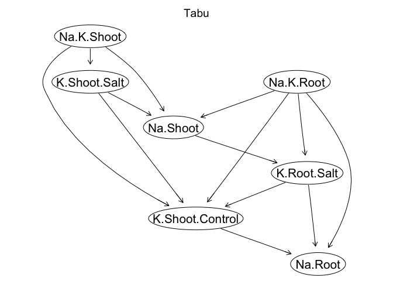

```r
# Score-based algorithm: Tabu Search
tabu_simple <- tabu(BV)
graphviz.plot(tabu_simple, main = "Tabu", shape = "ellipse", layout = "dot")
```

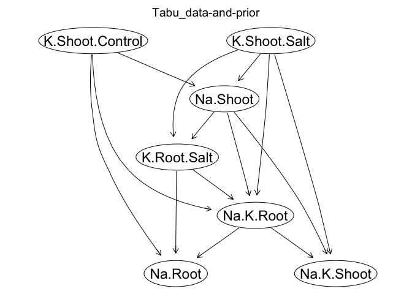

```r
# Incorporate subjective prior
whtlist <- c(from = 'Na.K.Root', to = 'Na.K.Shoot')
blklist <- data.frame(from = c("K.Shoot.Salt", "K.Shoot.Control" ),
                      to = c("K.Shoot.Control", "K.Shoot.Salt"))
# Data + subjective prior
tabu_blk <- tabu(BV, whitelist = whtlist, blacklist = blklist)
graphviz.plot(tabu_blk, main = "Tabu_data-and-prior", shape = "ellipse",
              layout = "dot")
```

## Remove the dependence in EBV with Cholesky Decomposition

```r
Linv <- solve(t(chol(grm)))
Minv <- kronecker(diag(7), Linv)
BV_adj <- matrix(Minv %*% c(as.matrix(BV)), nrow = 363, ncol = 7)
colnames(BV_adj) <- names(pheno)
BV_adj <- as.data.frame(BV_adj)
```

### Structure learning: data-driven approach

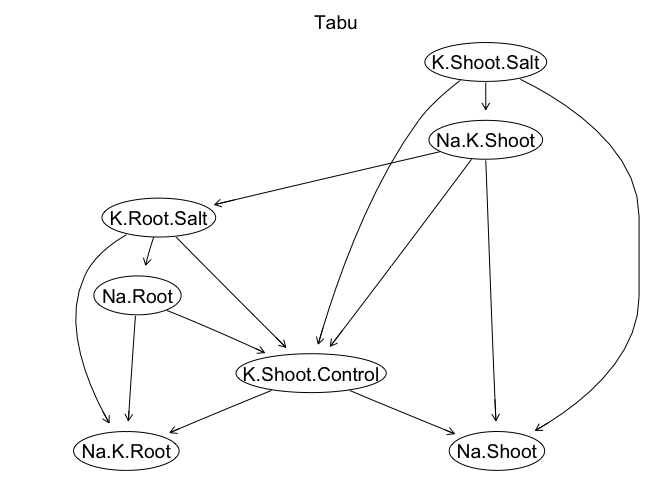

```r
# Score-based algorithm: Tabu Search
tabu_simple <- tabu(BV_adj)
graphviz.plot(tabu_simple, main = "Tabu", shape = "ellipse", layout = "dot")
```

```r
# Model Averaging with 500 bootstrap samples to account for uncertainty
set.seed(007)
boot_tabu <- boot.strength (BV_adj, algorithm = "tabu", R = 500)
# Check strength (>= 0.8) and direction (> 0.5)
check_boot(boot_tabu, 0.8, 0.5)
```

```
##            from              to strength direction
## 1    Na.K.Shoot        Na.Shoot    1.000 0.8300000
## 2    Na.K.Shoot    K.Shoot.Salt    1.000 0.6400000
## 6    Na.K.Shoot     K.Root.Salt    0.950 0.5105263
## 14 K.Shoot.Salt        Na.Shoot    0.954 0.7442348
## 15 K.Shoot.Salt K.Shoot.Control    1.000 0.9790000
## 35      Na.Root       Na.K.Root    1.000 0.6970000
## 40  K.Root.Salt K.Shoot.Control    0.956 0.9895397
## 41  K.Root.Salt       Na.K.Root    1.000 0.7730000
## 42  K.Root.Salt         Na.Root    1.000 0.6320000
```

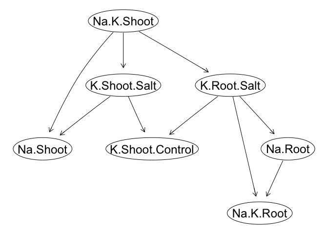

```r
# Average bootstrap samples use threshold = 0.8
ave_model_tabu <- averaged.network(boot_tabu, threshold = 0.8)
graphviz.plot(ave_model_tabu, shape = 'ellipse')
```

### Structure learning: data + prior knowledge

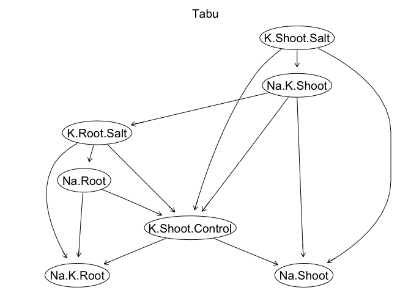

```r
# Score-based algorithm: Tabu Search
tabu_simple <- tabu(BV_adj)
graphviz.plot(tabu_simple, main = "Tabu", shape = "ellipse", layout = "dot")
```

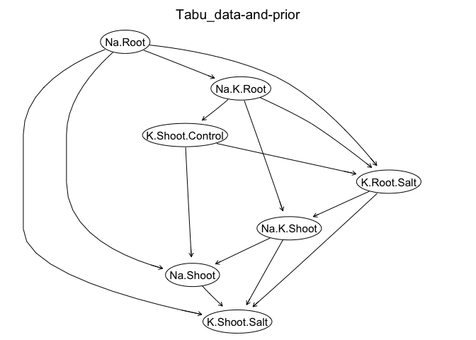

```r
# Incorporate subjective prior
whtlist <- c(from = 'Na.K.Root', to = 'Na.K.Shoot')
blklist <- data.frame(from = c("K.Shoot.Salt", "K.Shoot.Control" ),
                      to = c("K.Shoot.Control", "K.Shoot.Salt"))
# Data + subjective prior
tabu_blk <- tabu(BV_adj, whitelist = whtlist, blacklist = blklist)
graphviz.plot(tabu_blk, main = "Tabu_data-and-prior", shape = "ellipse",
              layout = "dot")
```

## Available BN learning algorithms in the `bnlearn` package

In the above examples, we used the score-based algorithm Tabu Search for structure learning. Alternatively, you can use other algorithms by replacing the `tabu()` function and the `algorithm = "tabu"` argument in the `boot.strength()` function with the followings. The details can be found in the help page of [bnlearn](http://www.bnlearn.com/).

- Score-based structure learning algorithms:
  - hc: Hill Climbing (HC)
  - tabu: Tabu Search (Tabu)
- Constraint-based structure learning algorithms:
  - pc.stable : the first practical application of the IC algorithm
  - gs: Grow-Shrink (GS)
  - iamb: Incremental Association Markov Blanket (IAMB)
  - fast.iamb: Fast Incremental Association (Fast-IAMB)
  - inter.iamb: Interleaved Incremental Association (Inter-IAMB)
  - mmpc: Max-Min Parents & Children (MMPC)
  - si.hiton.pc: Semi-Interleaved Hiton-PC (SI-HITON-PC)
- Hybrid structure learning algorithms:
  - mmhc: Max-Min Hill Climbing (MMHC)
  - rsmax2: General 2-Phase Restricted Maximization (RSMAX2)

## References

Morota, G, BD Valente, GJM Rosa, KA Weigel, and D Gianola. 2012. “An Assessment of Linkage Disequilibrium in Holstein Cattle Using a Bayesian Network.” *Journal of Animal Breeding and Genetics* 129 (6). Wiley Online Library: 474–87.

Scutari, Marco. 2010. “Learning Bayesian Networks with the Bnlearn R Package.” *Journal of Statistical Software, Articles* 35 (3): 1–22. doi:10.18637/jss.v035.i03.

Scutari, Marco, and Jean-Baptiste Denis. 2014. *Bayesian Networks: With Examples in R*. Chapman; Hall/CRC.

Yu, Haipeng, Malachy T Campbell, Qi Zhang, Harkamal Walia, and Gota Morota. 2019. “Genomic Bayesian Confirmatory Factor Analysis and Bayesian Network to Characterize a Wide Spectrum of Rice Phenotypes.” *G3: Genes, Genomes, Genetics*. G3: Genes, Genomes, Genetics, g3–400154.

Zhao, Keyan, Chih-Wei Tung, Georgia C Eizenga, Mark H Wright, M Liakat Ali, Adam H Price, Gareth J Norton, et al. 2011. “Genome-Wide Association Mapping Reveals a Rich Genetic Architecture of Complex Traits in Oryza Sativa.” *Nature Communications* 2. Nature Publishing Group: 467.